# Get started

This getting started guide aims to empower individuals without a programming background to engage in code-based plotting with tidyplots. We will start by covering essential software tools and discussing data preparation. Next, we will introduce the tidyplots workflow, which includes adding, removing, and adjusting plot components. Finally, we will showcase the application of themes and multiplot layouts.

# Prerequisites

You never generated code-based scientific plots? Great to have you here! To get you started, we will install a couple of software tools to setup your new working environment.

## Install R and RStudio Desktop

We will be using the programming language R and the software RStudio Desktop, which serves as an editor for your code but also comes with a bunch of additional features.

1. Download and install [R](https://cran.r-project.org) for your operating system. On Windows, choose the *base* version.
2. Download and install [RStudio Desktop](https://posit.co/download/rstudio-desktop/)

For more information about R programming have a look at the free online book [Hands-On Programming with R](https://rstudio-education.github.io/hopr/) by Garrett Grolemund, which has a chapter with detailed [installation instructions](https://rstudio-education.github.io/hopr/starting.html). For a quick video tour of the RStudio Desktop user interface check out [RStudio for the Total Beginner](https://www.youtube.com/watch?v=FIrsOBy5k58).

## Install packages

After opening RStudio, you will find your R console in the lower left corner. All code you enter in the console will be directly executed by R. Let’s start by installing some essential packages. Packages deliver additional functionality that is not built into base R.

```r
install.packages("tidyverse")
install.packages("tidyplots")
```

# Data preparation

Before starting to plot, the first thing is to ensure that your data is *tidy*. More formally, in tidy data

1. each *variable* must have its own column
2. each *observation* must have its own row and
3. each *value* must have its own cell

For more details about tidy data analysis have a look at the free online book [R for Data Science](https://r4ds.hadley.nz) by Hadley Wickham, which has a chapter dedicated to [tidy data](https://r4ds.hadley.nz/data-tidy).

tidyplots comes with a number of tidy demo dataset that are ready to use for plotting. We start by loading the tidyplots package and have a look at the `study` dataset.

```r
library(tidyplots)
study
```

```
#>    treatment     group dose participant age    sex score
#> 1          A   placebo high         p01  23 female     2
#> 2          A   placebo high         p02  45   male     4
#> 3          A   placebo high         p03  32 female     5
#> 4          A   placebo high         p04  37   male     4
#> 5          A   placebo high         p05  24 female     6
#> 6          B   placebo  low         p06  23 female     9
#> 7          B   placebo  low         p07  45   male     8
#> 8          B   placebo  low         p08  32 female    12
#> 9          B   placebo  low         p09  37   male    15
#> 10         B   placebo  low         p10  24 female    16
#> 11         C treatment high         p01  23 female    32
#> 12         C treatment high         p02  45   male    35
#> 13         C treatment high         p03  32 female    24
#> 14         C treatment high         p04  37   male    45
#> 15         C treatment high         p05  24 female    56
#> 16         D treatment  low         p06  23 female    23
#> 17         D treatment  low         p07  45   male    25
#> 18         D treatment  low         p08  32 female    21
#> 19         D treatment  low         p09  37   male    22
#> 20         D treatment  low         p10  24 female    23
```

As you can see, the `study` dataset consists of a table with 7 columns, also called *variables*, and 20 rows, also called *observations*. The study participants received 4 different kinds of `treatment` (A, B, C, or D) and a `score` was measured to assess treatment success.

# Plotting

Now it is time for the fun part! Make sure that you loaded the tidyplots package. This needs to be done once for every R session.

```r
library(tidyplots)
```

Then we start with the `study` dataset and pipe it into the `tidyplot()` function.

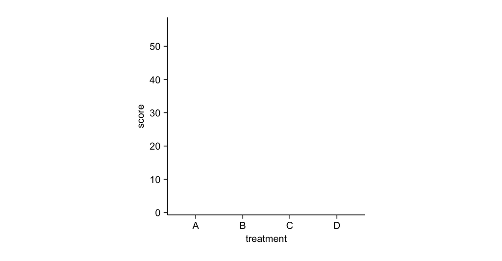

```r
study |>
  tidyplot(x = treatment, y = score)
```

And here it is, your first tidyplot! Admittedly, it still looks a little bit empty. We will take care of this in a second. But first let’s have a closer look at the code above.

In the first line we start with the `study` dataset. The `|>` is called a *pipe* and makes sure, that the output of the first line is handed over as input to the next line. In the second line, we generate the tidyplot and specify which variables we want to use for the x and y-axis using the `x` and `y` arguments of the `tidyplot()` function.

*Tip: The keyboard shortcut for the pipe is `Cmd` + `Shift` + `M` on the Mac and `Ctrl` + `Shift` + `M` on Windows.*

## Add

Next, let’s add some more elements to the plot. This is done by using a family of functions that all start with `add_`. For example, we can add the data points by adding one more line to the code. Note, that we need a `|>` at the end of each line, where the output should be piped into the next line. When you combine multiple lines like this, you have generated a *pipeline*.

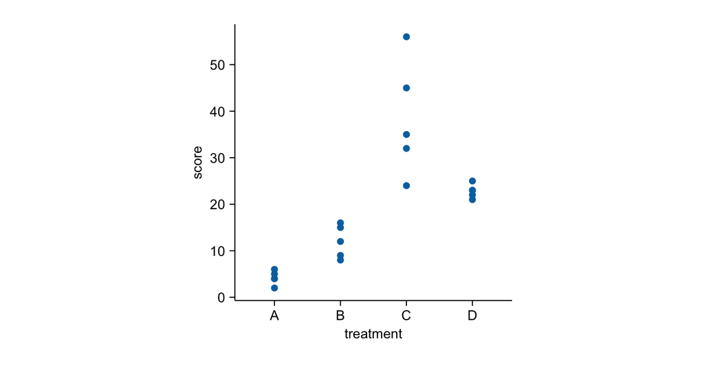

```r
study |>
  tidyplot(x = treatment, y = score) |>
  add_data_points()
```

Of course, you do not have to stop here. There are many `add_*()` functions you can choose from. An overview of all function in the tidyplots package can be found in the [Package index](https://jbengler.github.io/tidyplots/reference/index.html).

For now, let’s add some bars to the plot. As soon as you start typing “add” in RStudio you should see a little window next to your courser that shows all available function that start with “add” and can thus be used to build up your plot. You can also manually trigger the auto-completion window by hitting the `tab` key.

In tidyplots, function names that start with `add_` usually continue with the statistical entity to plot, e.g. `mean`, `median`, `count`, etc. As a next piece, you decide which graphical representation to use, e.g. `bar`, `dash`, `line` etc. In our example we choose `add_mean_bar()` to show the mean value of each treatment group represented as a bar.

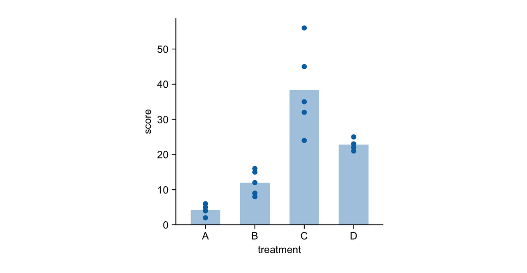

```r
study |>
  tidyplot(x = treatment, y = score) |>
  add_data_points() |>
  add_mean_bar(alpha = 0.4)
```

One thing to note here is that I added `alpha = 0.4` as a argument to the `add_mean_bar()` function. This adds a little transparency to the bars and results in a lighter blue color in comparison to the data points.

Some people might do not like bars so much. So let’s exchange the `bar` for a `dash`. And while we are on it, let’s add the standard error of the mean `sem`, represented as error bar.

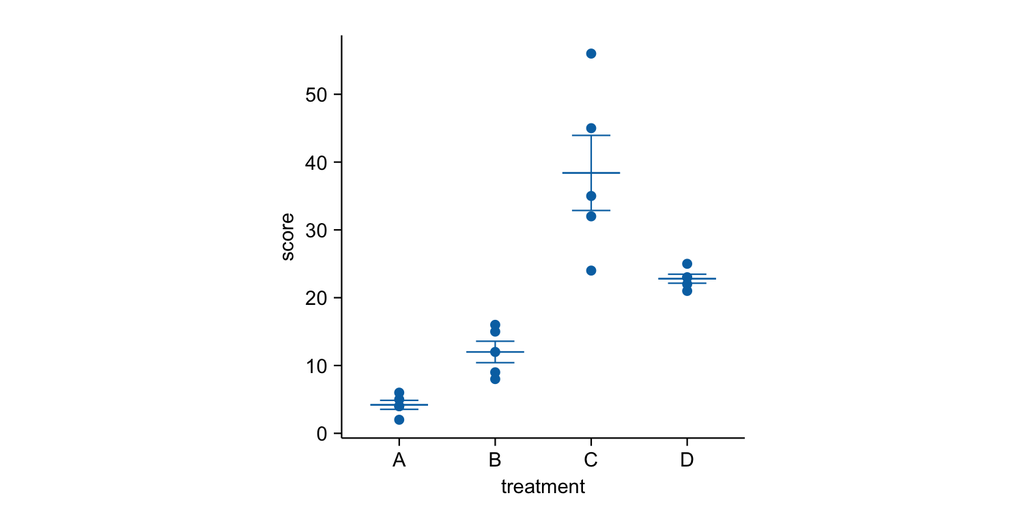

```r
study |>
  tidyplot(x = treatment, y = score) |>
  add_data_points() |>
  add_mean_dash() |>
  add_sem_errorbar()
```

I think by now you got the principle. You can just keep adding layers until your plot has all the elements you need.

But there is one more building block that we need to cover and that is color. Color is a very powerful way to encode information in a plot. As colors can encode *variables* in a similar way as axes, the argument `color` needs to be to provided in the initial call of the `tidyplot()` function.

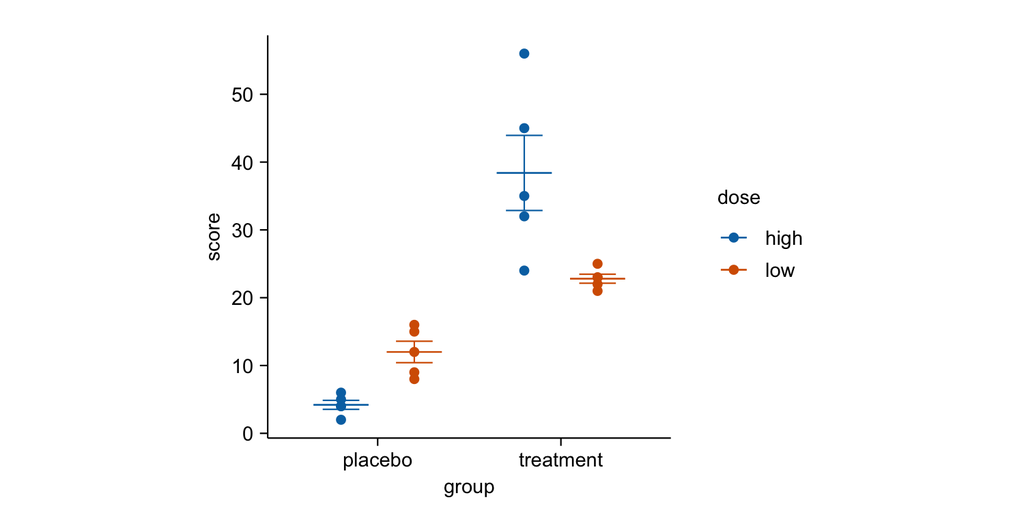

```r
study |>
  tidyplot(x = group, y = score, color = dose) |>
  add_data_points() |>
  add_mean_dash() |>
  add_sem_errorbar()
```

As you can see, `color` acts as a way to group the data by a third *variable*, thus complementing the `x` and `y` axis.

Although there are many more `add_*()` functions available, I will stop here and leave you with the [Package index](https://jbengler.github.io/tidyplots/reference/index.html) and the article about [Visualizing data](https://jbengler.github.io/tidyplots/articles/Visualizing-data.html) for further inspiration.

## Remove

Besides adding plot elements, you might want to remove certain parts of the plot. This can be achieved with the `remove_*()` family of functions. For example, you might want to remove the color legend title, or in some rare cases even the entire y-axis.

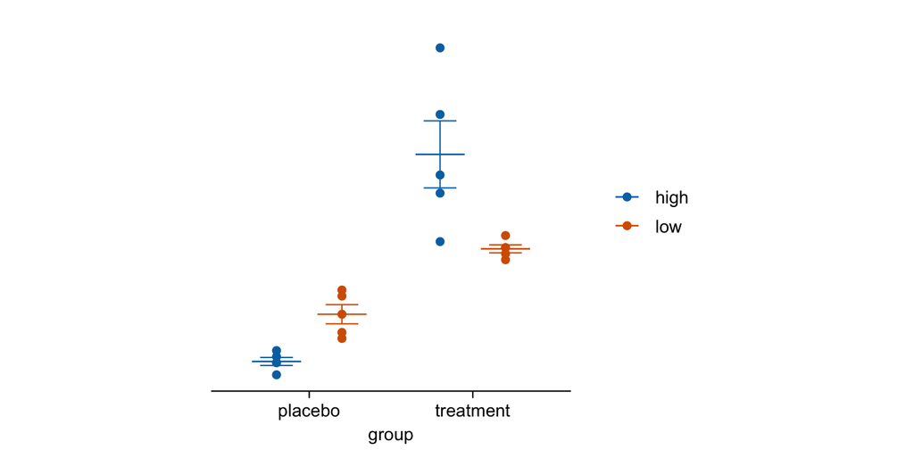

```r
study |>
  tidyplot(x = group, y = score, color = dose) |>
  add_data_points() |>
  add_mean_dash() |>
  add_sem_errorbar() |>
  remove_legend_title() |>
  remove_y_axis()
```

More `remove_*()` functions can be found in the [Package index](https://jbengler.github.io/tidyplots/reference/index.html).

## Adjust

After you have assembled your plot, you often want to tweak some details about how the plot or its components are displayed. For this task, tidyplots provides a number of `adjust_*()` functions.

Let’s start with this plot.

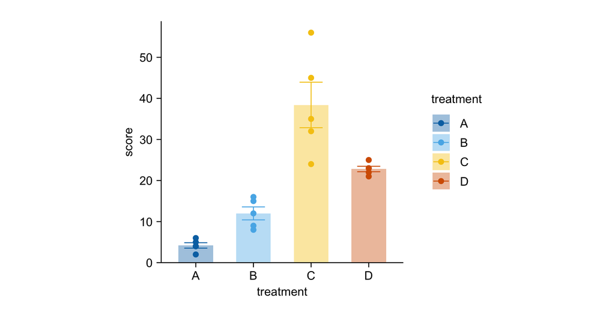

```r
study |>
  tidyplot(x = treatment, y = score, color = treatment) |>
  add_data_points() |>
  add_mean_bar(alpha = 0.4) |>
  add_sem_errorbar()
```

When preparing figures for a paper, you might want ensure, that all plots have a consistent size. The default in tidyplots is a width of 50 mm and a height of 50 mm. Please note that these values refer to size of the *plot area*, which is the area enclosed by the x and y-axis. Therefore labels, titles, and legends are not counting towards the *plot area size*.

This is perfect to achieve a consistent look, which is most easily done by selecting a consistent `height` across plots, while the `width` can vary depending on the number of categories in the x-axis.

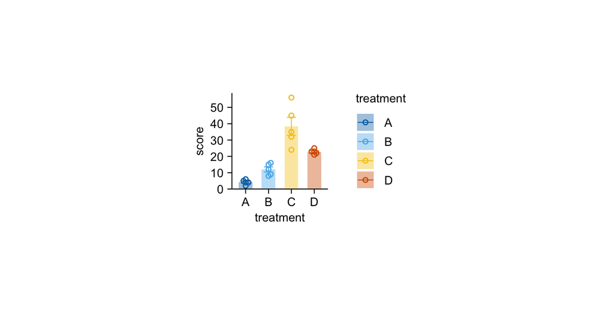

```r
study |>
  tidyplot(x = treatment, y = score, color = treatment) |>
  add_data_points_beeswarm(shape = 1) |>
  add_mean_bar(alpha = 0.4) |>
  add_sem_errorbar() |>
  adjust_size(width = 20, height = 20)
```

Another common adjustment is to change the titles of the plot, axes, or legend. For this we will use the function `adjust_title()` and friends.

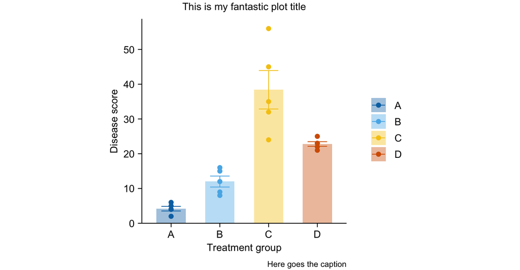

```r
study |>
  tidyplot(x = treatment, y = score, color = treatment) |>
  add_data_points() |>
  add_mean_bar(alpha = 0.4) |>
  add_sem_errorbar() |>
  adjust_title("This is my fantastic plot title") |>
  adjust_x_axis_title("Treatment group") |>
  adjust_y_axis_title("Disease score") |>
  adjust_legend_title("") |>
  adjust_caption("Here goes the caption")
```

Note that I removed the legend title by setting it to an empty string `adjust_legend_title("")`. This is alternative to `remove_legend_title()`, however the result is not exactly the same. I am sure you will figure out the difference.

Another common task is to adjust the colors in your plot. You can do this using the `adjust_colors()` function.

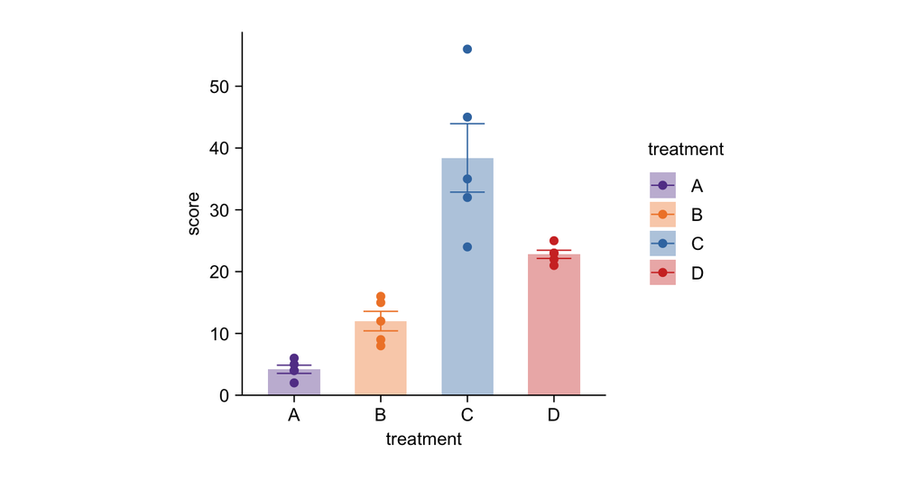

```r
study |>
  tidyplot(x = treatment, y = score, color = treatment) |>
  add_data_points() |>
  add_mean_bar(alpha = 0.4) |>
  add_sem_errorbar() |>
  adjust_colors(new_colors = c("#644296","#F08533","#3B78B0", "#D1352C"))
```

You can also use the color schemes, that are built into tidyplots. To learn more about these color schemes have a look at the article [Color schemes](https://jbengler.github.io/tidyplots/articles/Color-schemes.html).

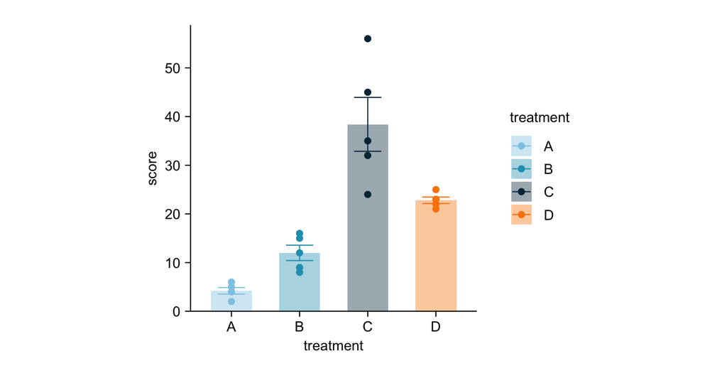

```r
study |>
  tidyplot(x = treatment, y = score, color = treatment) |>
  add_data_points() |>
  add_mean_bar(alpha = 0.4) |>
  add_sem_errorbar() |>
  adjust_colors(new_colors = colors_discrete_seaside)
```

**Rename, reorder, sort, and reverse**

A special group of adjust functions deals with the *data labels* in your plot. These function are special because they need to modify the underlying data of the plot. Moreover, they do not start with `adjust_` but with `rename_`, `reorder_`, `sort_`, and `reverse_`.

For example, to rename the data labels for the `treatment` variable on the x-axis, you can do this.

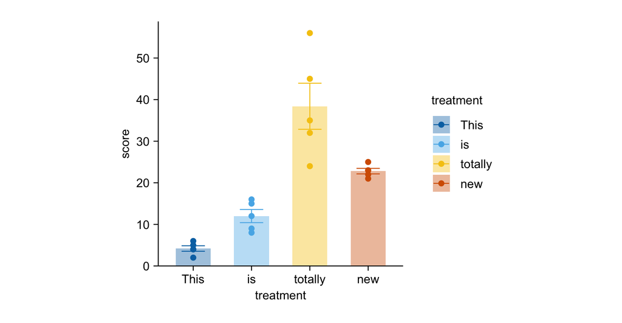

```r
study |>
  tidyplot(x = treatment, y = score, color = treatment) |>
  add_data_points() |>
  add_mean_bar(alpha = 0.4) |>
  add_sem_errorbar() |>
  rename_x_axis_labels(new_names = c("A" = "This",
                                     "B" = "is",
                                     "C" = "totally",
                                     "D" = "new"))
```

Note that we provide a *named character vector* to make it clear which old label should be replace with which new label.

The remaining functions, starting with `reorder_`, `sort_`, and `reverse_`, do not change the name of the label but their order in the plot.

For example, you can bring the treatment “D” and “C” to the front.

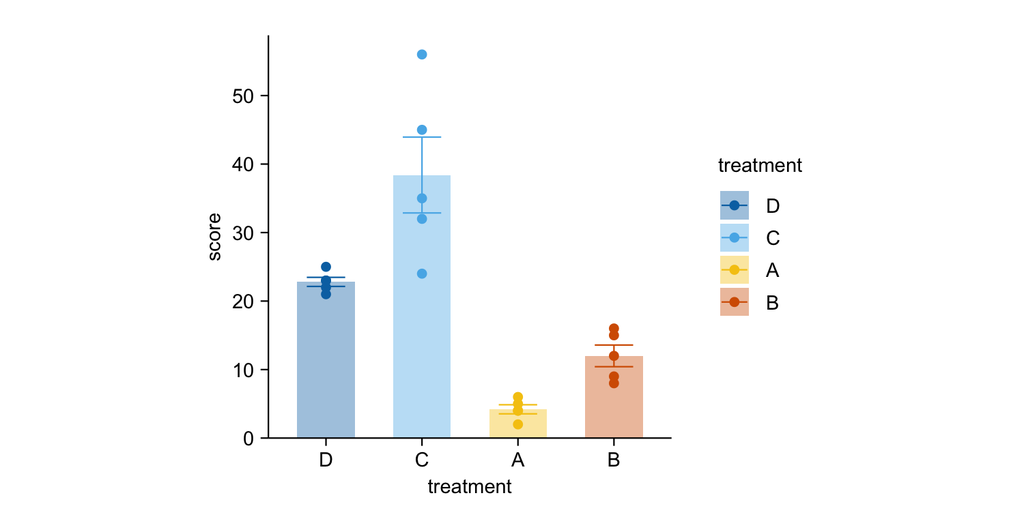

```r
study |>
  tidyplot(x = treatment, y = score, color = treatment) |>
  add_data_points() |>
  add_mean_bar(alpha = 0.4) |>
  add_sem_errorbar() |>
  reorder_x_axis_labels("D", "C")
```

Sort the treatments by their score.

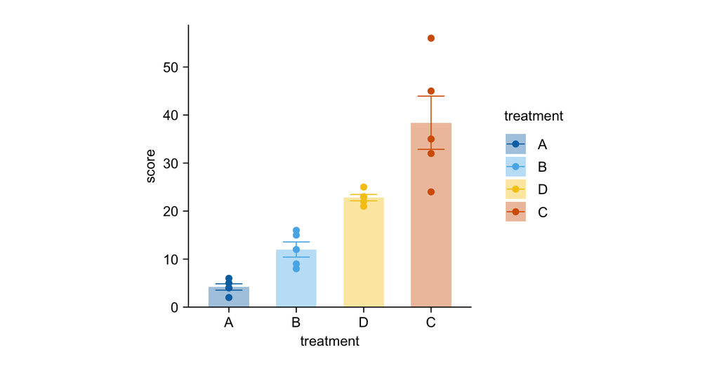

```r
study |>
  tidyplot(x = treatment, y = score, color = treatment) |>
  add_data_points() |>
  add_mean_bar(alpha = 0.4) |>
  add_sem_errorbar() |>
  sort_x_axis_labels()
```

Or simply reverse the order of the labels.

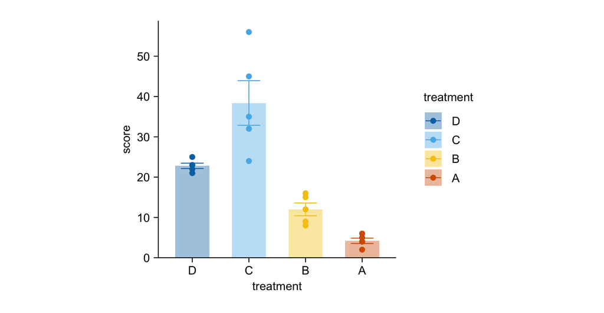

```r
study |>
  tidyplot(x = treatment, y = score, color = treatment) |>
  add_data_points() |>
  add_mean_bar(alpha = 0.4) |>
  add_sem_errorbar() |>
  reverse_x_axis_labels()
```

Of course, there are many more `adjust_` functions that you can find in the [Package index](https://jbengler.github.io/tidyplots/reference/index.html).

## Themes

Themes are a great way to modify the look an feel of your plot without changing the representation of the data. You can stay with the default tidyplots theme.

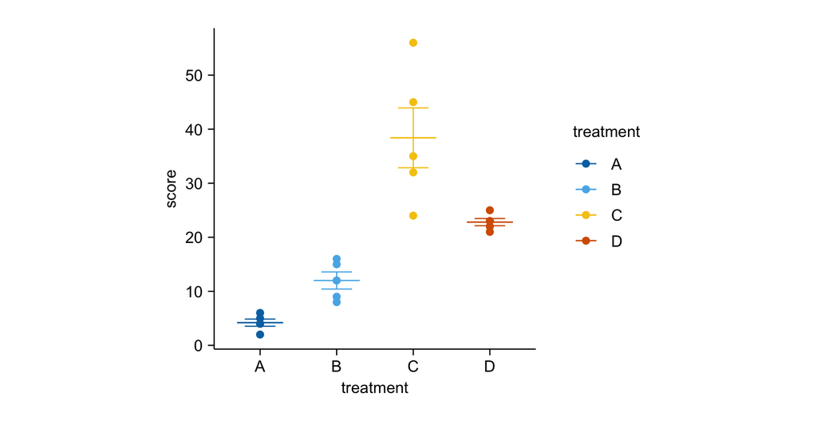

```r
study |>
  tidyplot(x = treatment, y = score, color = treatment) |>
  add_data_points() |>
  add_sem_errorbar() |>
  add_mean_dash() |>
  theme_tidyplot()
```

Or try something more like ggplot2.

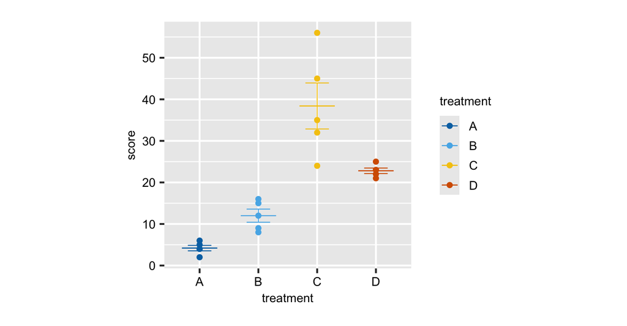

```r
study |>
  tidyplot(x = treatment, y = score, color = treatment) |>
  add_data_points() |>
  add_sem_errorbar() |>
  add_mean_dash() |>
  theme_ggplot2()
```

Or something more minimal.

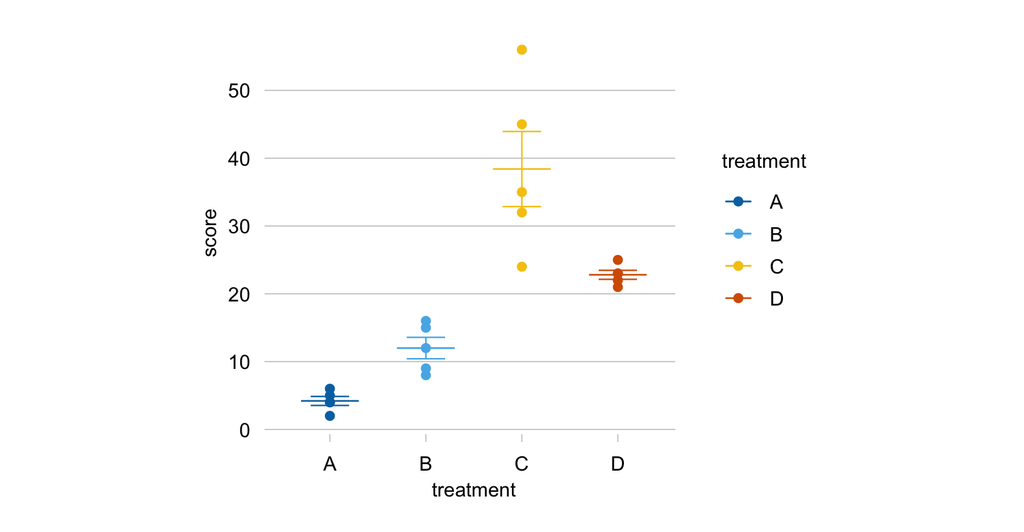

```r
study |>
  tidyplot(x = treatment, y = score, color = treatment) |>
  add_data_points() |>
  add_sem_errorbar() |>
  add_mean_dash() |>
  theme_minimal_y() |>
  remove_x_axis_line()
```

## Split

When you have a complex dataset, you might want split the plot into multiple subplots. In tidyplots, this can be done with the function `split_plot()`.

Starting with the `study` dataset, you could plot the `score` against the treatment `group` and split this plot by `dose` into a high dose and a low dose plot.

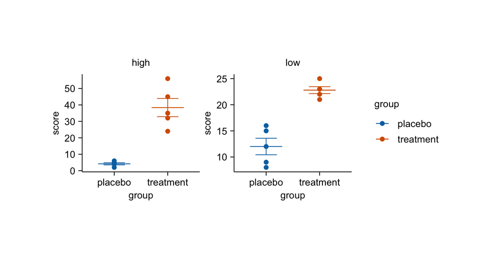

```r
study |>
  tidyplot(x = group, y = score, color = group) |>
  add_data_points() |>
  add_sem_errorbar() |>
  add_mean_dash() |>
  adjust_size(width = 30, height = 25) |>
  split_plot(by = dose)
```

## Output

The classical way to output a plot is to write it to a PDF or PNG file. This can be easily done by piping the plot into the function `save_plot()`.

```r
study |>
  tidyplot(x = group, y = score, color = group) |>
  add_data_points() |>
  add_sem_errorbar() |>
  add_mean_dash() |>
  save_plot("my_plot.pdf")
```

Conveniently, `save_plot()` also gives back the plot it received, allowing it to be used in the middle of a pipeline. If `save_plot()` is a the end of pipeline, the plot will be rendered on screen, providing a visual confirmation of what was saved to file.

# What’s more?

To dive deeper into code-based plotting, here a couple of resources.

## tidyplots documentation

- [Package index](https://jbengler.github.io/tidyplots/reference/index.html)  
  Overview of all tidyplots functions
- [Get started](https://jbengler.github.io/tidyplots/articles/tidyplots.html)  
  Getting started guide
- [Visualizing data](https://jbengler.github.io/tidyplots/articles/Visualizing-data.html)  
  Article with examples for common data visualizations
- [Advanced plotting](https://jbengler.github.io/tidyplots/articles/Advanced-plotting.html)  
  Article about advanced plotting techniques and workflows
- [Color schemes](https://jbengler.github.io/tidyplots/articles/Color-schemes.html)  
  Article about the use of color schemes

## Other resources

- [Hands-On Programming with R](https://rstudio-education.github.io/hopr/)  
  Free online book by Garrett Grolemund
- [R for Data Science](https://r4ds.hadley.nz)  
  Free online book by Hadley Wickham
- [Fundamentals of Data Visualization](https://clauswilke.com/dataviz/)  
  Free online book by Claus O. Wilke